# homework 3

Julietta Ghazaryan

March 4, 2019

*For this Homework, you are required to submit both Markdown and HTML files with your answers and code in it. Be sure that the .Rmd file is working, so when I run it, there would be no errors and represent the same information as HTML. Write your code and interpretations under each question. The interpretations of the results need to be written below or above all the charts, summaries, or tables. Do not remove problems from your Markdown file.*

Use biodata.csv dataset uploaded on Moodle to analyze the relationship between the presence of kidney disease and different factors. The description of the variables is given in a separate file. Pay close attention to the names of axes, titles, and labels.

**Problem 1. 2 pt.**

Load the file.

```r
Bio<-read.csv("biodata.csv",na.strings = "?")
str(Bio)
```

```
## 'data.frame':    381 obs. of  21 variables:
##  $ id   : int  1 2 3 4 5 6 7 8 9 10 ...
##  $ age  : int  48 7 62 48 51 60 68 24 52 53 ...
##  $ bp   : int  80 50 80 70 80 90 70 NA 100 90 ...
##  $ su   : int  0 0 3 0 0 0 0 4 0 0 ...
##  $ rbc  : Factor w/ 2 levels "abnormal","normal": 1 1 2 2 2 1 1 2 2 1 ...
##  $ ba   : Factor w/ 2 levels "notpresent","present": 1 1 1 1 1 1 1 1 1 1 ...
##  $ bgr  : int  121 NA 423 117 106 74 100 410 138 70 ...
##  $ sc   : num  1.2 0.8 1.8 3.8 1.4 1.1 24 1.1 1.9 7.2 ...
##  $ sod  : num  NA NA NA 111 NA 142 104 NA NA 114 ...
##  $ pot  : num  NA NA NA 2.5 NA 3.2 4 NA NA 3.7 ...
##  $ hemo : num  15.4 11.3 9.6 11.2 11.6 12.2 12.4 12.4 10.8 9.5 ...
##  $ pcv  : int  44 38 31 32 35 39 36 44 33 29 ...
##  $ wbcc : int  7800 6000 7500 6700 7300 7800 NA 6900 9600 12100 ...
##  $ rbcc : num  5.2 NA NA 3.9 4.6 4.4 NA 5 4 3.7 ...
##  $ htn  : Factor w/ 2 levels "no","yes": 2 1 1 2 1 2 1 1 2 2 ...
##  $ dm   : Factor w/ 2 levels "no","yes": 2 1 2 1 1 2 1 2 2 2 ...
##  $ cad  : Factor w/ 2 levels "no","yes": 1 1 1 1 1 1 1 1 1 1 ...
##  $ appet: Factor w/ 2 levels "good","poor": 1 1 2 2 1 1 1 1 1 2 ...
##  $ pe   : Factor w/ 2 levels "no","yes": 1 1 1 2 1 2 1 2 1 1 ...
##  $ ane  : Factor w/ 2 levels "no","yes": 1 1 2 2 1 1 1 1 2 2 ...
##  $ class: int  1 1 1 1 1 1 1 1 1 1 ...
```

Get rid of variables which are irrelevant for logistic regression analysis using function select(). Also, skip variables which are absent in .txt file).

We need to get rid of “id” as it is unique for each observation, thus cannot be considered as factor causing chronic kidney disease. We also need to drop variables “pcv”,“sc” and “pv” as they are not included in the txt file.

```r
library(dplyr)
Bio<-select(Bio,-c(1,8,12,19))
```

Check whether the data types are correct, if not make appropriate corrections assigning labels to each level according to the data description.

Make variable “class” (presence of chronic kidney disease) as factor with appropriate lables to its levels. Also make variable “su” (sugar) as factor.

```r
Bio$class<-factor(Bio$class, levels=c(0,1), labels=c("No ch. kidney disease ","chronic kidney disease"))

Bio$su<-ordered(Bio$su,levels=c(0,1,2,3,4,5))
```

For all **numeric** variables replace missing values by column mean.

```r
for (i in c(1:2,6:11)){
    Bio[is.na(Bio[,i]),i]<-mean(Bio[,i],na.rm=TRUE)
}
```

Create new dataset without missing data (remove observations with missing values for **categorical** variables)

```r
Bio_final<-na.omit(Bio)
```

How many variables and observations do you have before and now?

At the beginning we had 381 observations and 21 variables, after modifications (now) we have 322 observations and 17 variables.

```r
str(Bio_final)
```

```
## 'data.frame':    322 obs. of  17 variables:
##  $ age  : num  48 7 62 48 51 60 68 24 52 53 ...
##  $ bp   : num  80 50 80 70 80 ...
##  $ su   : Ord.factor w/ 6 levels "0"<"1"<"2"<"3"<..: 1 1 4 1 1 1 1 5 1 1 ...
##  $ rbc  : Factor w/ 2 levels "abnormal","normal": 1 1 2 2 2 1 1 2 2 1 ...
##  $ ba   : Factor w/ 2 levels "notpresent","present": 1 1 1 1 1 1 1 1 1 1 ...
##  $ bgr  : num  121 146 423 117 106 ...
##  $ sod  : num  138 138 138 111 138 ...
##  $ pot  : num  4.65 4.65 4.65 2.5 4.65 ...
##  $ hemo : num  15.4 11.3 9.6 11.2 11.6 12.2 12.4 12.4 10.8 9.5 ...
##  $ wbcc : num  7800 6000 7500 6700 7300 ...
##  $ rbcc : num  5.2 4.72 4.72 3.9 4.6 ...
##  $ htn  : Factor w/ 2 levels "no","yes": 2 1 1 2 1 2 1 1 2 2 ...
##  $ dm   : Factor w/ 2 levels "no","yes": 2 1 2 1 1 2 1 2 2 2 ...
##  $ cad  : Factor w/ 2 levels "no","yes": 1 1 1 1 1 1 1 1 1 1 ...
##  $ appet: Factor w/ 2 levels "good","poor": 1 1 2 2 1 1 1 1 1 2 ...
##  $ ane  : Factor w/ 2 levels "no","yes": 1 1 2 2 1 1 1 1 2 2 ...
##  $ class: Factor w/ 2 levels "No ch. kidney disease ",..: 2 2 2 2 2 2 2 2 2 2 ...
##  - attr(*, "na.action")=Class 'omit'  Named int [1:59] 20 29 38 51 58 60 61 78 86 87 ...
##   .. ..- attr(*, "names")= chr [1:59] "20" "29" "38" "51" ...
```

**Problem 2. 3 pt.**

1. Check the relationship between each numeric variable and the presence of kidney disease. Save only the two most important numeric variables using boxplots. Comment on it.

For variable “hemo” standing for hemoglobin concentration in blood means for people with and without chronic kidney disease are different. I think the difference is important as max value for hemoglobin concentration is 17.8 and mean value is 12,than 15, which is the average value of hemoglobin for people without chronic kidney disease,is close to the max value for hemoglobin, and almost 11, which is the average value of hemoglobin for people with chronic kidney disease, is less then the overall mean value of hemoglobin. So hemoglobin concentration is important according to the visualisation. The boxplot shows that hemoglobin is on average higher for people who do not have chronic kidney disease than for people with chronic kidney disease. But we cannot say anything about causation here.

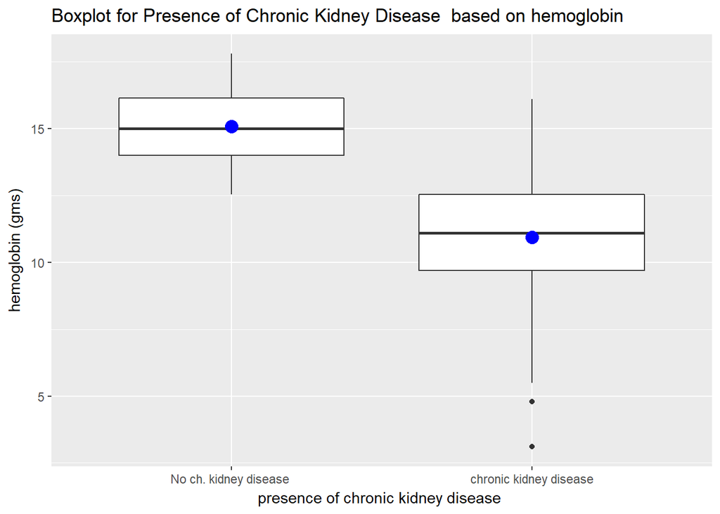

```r
library(ggplot2)

ggplot(Bio_final, aes(class,hemo))+
geom_boxplot()+
stat_summary(fun.y="mean", geom="point", size=4, col="blue")+
ggtitle("Boxplot for Presence of Chronic Kidney Disease  based on hemoglobin")+
ylab("hemoglobin (gms)")+
xlab("presence of chronic kidney disease ")
```

```r
by(Bio_final$hemo,Bio_final$class,mean)
```

```
## Bio_final$class: No ch. kidney disease
## [1] 15.08647
## --------------------------------------------------------
## Bio_final$class: chronic kidney disease
## [1] 10.93142
```

```r
#max value for variable "hemo"
max(Bio_final$hemo)
```

```
## [1] 17.8
```

```r
#average value of variable "hemo"
mean(Bio_final$hemo)
```

```
## [1] 12.72506
```

Mean number of red blood cells for people with and without chronic kidney disease are somewhat different. We can say that for people who do not have chronic kidney disease number of red blood cells are on average higher than for people who have chronic kidney disease

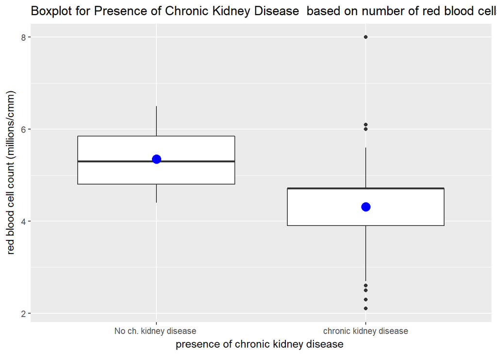

```r
ggplot(Bio_final, aes(class,rbcc))+
geom_boxplot()+
stat_summary(fun.y="mean", geom="point", size=4, col="blue")+
ggtitle("Boxplot for Presence of Chronic Kidney Disease  based on number of red blood cells")+
ylab("red blood cell count (millions/cmm)")+
xlab("presence of chronic kidney disease ")
```

```r
by(Bio_final$rbcc,Bio_final$class,mean)
```

```
## Bio_final$class: No ch. kidney disease
## [1] 5.349815
## --------------------------------------------------------
## Bio_final$class: chronic kidney disease
## [1] 4.31471
```

2. Use the glm() function to perform a logistic regression with Class as the response and one of **numeric** variables as the predictor (use results of 2a). Use the summary() function to print the result. Is your explanatory variable significant? Why?